# Machine Learning - Individual Project

**Task:** This dataset is composed of 1300 samples with 30 features each. The first column is the sample id. The second column in the dataset represents the label. There are 4 possible values for the labels. The remaining columns are numeric features.

Your task is the following: you should compare the performance of a Support Vector Machine (implemented by sklearn.svm.LinearSVC) with that of Logistic Regression (implemented by sklearn.linear_model.LogisticRegression). Try to optimize both algorithms' parameters and determine which one is best for this dataset. At the end of the analysis, you should have chosen an algorithm and its optimal set of parameters: write this choice explicitly in the conclusions of your notebook.

Your notebook should detail the procedure you have used to choose the optimal parameters (graphs are a good idea when possible/sensible).

The notebook will be evaluated not only based on the final results, but also on the procedure employed, which should balance practical considerations (one may not be able to exhaustively explore all possible combinations of the parameters) with the desire for achieving the best possible performance in the least amount of time.

Bonus points may be assigned for particularly clean/nifty code and/or well presented results.

You are also free to attempt other strategies beyond the one in the assignment (which however is mandatory!).

## Exploratoy Data Analysis

First, we import the necessary file and some basic libraries

```python
import numpy as np
import pandas as pd
import matplotlib.pyplot as plt
import seaborn as sns
%matplotlib inline

plt.style.use('seaborn-v0_8')
```

```python
df = pd.read_csv('mldata_0003194123.csv', index_col='Unnamed: 0')
df
```

|  | label | feature_1 | feature_2 | feature_3 | feature_4 | feature_5 | feature_6 | feature_7 | feature_8 | feature_9 | ... | feature_21 | feature_22 | feature_23 | feature_24 | feature_25 | feature_26 | feature_27 | feature_28 | feature_29 | feature_30 |
| --- | --- | --- | --- | --- | --- | --- | --- | --- | --- | --- | --- | --- | --- | --- | --- | --- | --- | --- | --- | --- | --- |
| 0 | 2 | 0.276402 | 2.760322 | 1.634573 | 1.971703 | -2.567100 | 1.751906 | -2.951297 | -0.377949 | 3.768138 | ... | -1.597400 | 3.522036 | 1.909411 | 2.700785 | 2.438567 | -0.578821 | 0.750711 | -0.172254 | -1.445176 | 1.297926 |
| 1 | 1 | 1.162337 | 1.469832 | -0.627212 | 2.820121 | 3.213237 | 1.692130 | -0.990517 | 4.072689 | 1.517013 | ... | -2.244819 | 4.755567 | 6.090020 | -3.254066 | 7.037773 | 1.421778 | -3.204494 | -1.937917 | 0.180691 | 1.931026 |
| 2 | 2 | 0.590380 | -3.611252 | 4.050163 | -0.879946 | -0.158516 | 1.904605 | -3.089397 | 4.798737 | -6.393072 | ... | 0.088229 | 2.766467 | 0.908493 | -1.981545 | 1.397158 | 0.356646 | -2.184492 | 0.174487 | 2.076749 | 0.953160 |
| 3 | 1 | 0.935988 | 2.189853 | -2.204155 | -0.301172 | -3.892313 | 3.525759 | -2.881390 | 4.676962 | 9.988963 | ... | -2.396826 | -0.659753 | 6.058849 | 3.351643 | 3.321225 | 2.274599 | 4.298476 | 0.235290 | -2.228258 | 2.601548 |
| 4 | 1 | 1.835614 | -2.240760 | 2.347787 | 2.943928 | 0.902176 | -0.632695 | 0.330264 | 3.787671 | -2.339007 | ... | -1.021328 | 2.987733 | 3.022541 | -2.487878 | 3.384212 | -4.798981 | -0.116116 | -3.496755 | 1.018822 | -3.279515 |
| ... | ... | ... | ... | ... | ... | ... | ... | ... | ... | ... | ... | ... | ... | ... | ... | ... | ... | ... | ... | ... | ... |
| 1295 | 0 | 1.738712 | -0.651443 | 1.788399 | 0.550431 | -2.446528 | -4.755604 | 0.467721 | -0.316659 | -3.298263 | ... | -2.532577 | 1.279362 | -0.317502 | -1.512451 | -4.651890 | -0.450840 | -1.487973 | 0.794417 | 1.226039 | 1.009882 |
| 1296 | 1 | -3.818004 | -3.349195 | 1.076156 | -0.357880 | 1.203743 | 2.293377 | -0.878649 | 0.180859 | -3.306783 | ... | 0.942685 | -1.564939 | 2.512485 | 2.236170 | 0.641019 | -1.189488 | -1.210559 | -1.782360 | 1.545358 | -1.769229 |
| 1297 | 2 | 0.170514 | 1.132277 | -0.652662 | 1.652612 | 0.590584 | 0.011290 | -7.963937 | -2.294285 | -0.412506 | ... | -1.001394 | 3.258110 | -1.234318 | 1.571219 | 1.948773 | -2.074732 | 0.199257 | -0.191647 | 1.484046 | -3.749649 |
| 1298 | 1 | -2.863604 | -1.821823 | -2.568710 | -1.600668 | -1.602603 | 1.610865 | 1.444222 | -1.716508 | -4.864763 | ... | 1.337301 | -0.788140 | -1.335829 | 0.111930 | -1.892559 | -1.665395 | 1.830377 | 0.379273 | 1.571891 | -1.257880 |
| 1299 | 1 | -1.357075 | -2.055295 | 1.913274 | 5.987259 | 1.437721 | 0.022430 | -1.254054 | -0.096349 | -6.813938 | ... | 0.369260 | -0.753759 | 0.767155 | 4.221383 | 3.603132 | 2.331166 | -0.644413 | -0.354944 | 0.725617 | -3.475484 |

1300 rows × 31 columns

### Preprocessing

We first take a look at the dataset

```python
df.describe()
```

|  | label | feature_1 | feature_2 | feature_3 | feature_4 | feature_5 | feature_6 | feature_7 | feature_8 | feature_9 | ... | feature_21 | feature_22 | feature_23 | feature_24 | feature_25 | feature_26 | feature_27 | feature_28 | feature_29 | feature_30 |
| --- | --- | --- | --- | --- | --- | --- | --- | --- | --- | --- | --- | --- | --- | --- | --- | --- | --- | --- | --- | --- | --- |
| count | 1300.000000 | 1300.000000 | 1300.000000 | 1300.000000 | 1300.000000 | 1300.000000 | 1300.000000 | 1300.000000 | 1300.000000 | 1300.000000 | ... | 1300.000000 | 1300.000000 | 1300.000000 | 1300.000000 | 1300.000000 | 1300.000000 | 1300.000000 | 1300.000000 | 1300.000000 | 1300.000000 |
| mean | 1.529231 | -0.226240 | -1.102151 | -0.195093 | -0.172830 | -0.070207 | 0.068472 | -0.653588 | -0.143146 | -1.321409 | ... | -0.296419 | 0.736407 | 0.305752 | 0.199016 | 0.067905 | -0.395139 | -0.050446 | -0.205237 | 0.329735 | -0.554959 |
| std | 1.126314 | 1.961194 | 3.345715 | 2.804093 | 3.203269 | 2.688318 | 2.118737 | 3.040208 | 2.019540 | 4.918566 | ... | 2.293354 | 2.326905 | 2.346543 | 2.379640 | 3.666075 | 2.850739 | 2.647774 | 1.971129 | 1.757733 | 2.465629 |
| min | 0.000000 | -7.288856 | -11.832930 | -11.355959 | -11.328164 | -11.377089 | -8.468697 | -9.811625 | -6.819311 | -18.529887 | ... | -8.285467 | -6.626036 | -7.229772 | -9.789430 | -13.111577 | -10.325207 | -10.493101 | -7.048643 | -5.843082 | -10.543714 |
| 25% | 1.000000 | -1.481125 | -3.448460 | -1.939271 | -2.206625 | -1.922399 | -1.286566 | -2.773885 | -1.592863 | -4.750745 | ... | -1.826881 | -0.791199 | -1.269838 | -1.350601 | -2.292694 | -2.194847 | -1.822174 | -1.516150 | -0.855171 | -2.146140 |
| 50% | 2.000000 | -0.207026 | -1.122637 | 0.052449 | -0.195072 | -0.146589 | 0.127612 | -0.578654 | -0.199047 | -1.145880 | ... | -0.331732 | 0.641784 | 0.331301 | 0.212559 | 0.051638 | -0.294127 | -0.068882 | -0.223458 | 0.374008 | -0.583825 |
| 75% | 3.000000 | 1.106593 | 1.130503 | 1.774368 | 1.980058 | 1.655517 | 1.552088 | 1.456315 | 1.179371 | 2.056086 | ... | 1.207545 | 2.299189 | 1.909979 | 1.745646 | 2.534285 | 1.505088 | 1.657739 | 1.056604 | 1.491359 | 1.013595 |
| max | 3.000000 | 5.704117 | 10.787729 | 8.965615 | 11.534110 | 8.444147 | 8.654119 | 8.966401 | 7.470686 | 15.755885 | ... | 7.587197 | 7.627682 | 7.310927 | 7.950010 | 15.012253 | 9.701695 | 10.591150 | 6.796947 | 7.852934 | 9.296404 |

8 rows × 31 columns

Check if there are some Null values

```python
df.isna().sum().sum()
```

```
0
```

We then check if the Dataset is balanced, and store the proportion of the classes for the classification that we will perform later on.

```python
class_frequencies = dict()
for i in range(4):
    class_frequencies[i] = round(df[df['label']==i].shape[0]/df.shape[0], 3)
    print(f'Percentage of {i}-labeled data: {class_frequencies[i]}')
```

```
Percentage of 0-labeled data: 0.244
Percentage of 1-labeled data: 0.248
Percentage of 2-labeled data: 0.242
Percentage of 3-labeled data: 0.265
```

We can safely conclude that the data we have are pretty much balanced and without any Null values.

Now we plot the features in an histogram, in order to grasp better their distribution, since with .describe() we don't really see much.

```python
def plot_features(df: pd.DataFrame) -> None:
    '''
    This function plots the features of the dataset. It takes a dataframe as input.
    '''

    fig, ax = plt.subplots(6, 5)

    fig.set_size_inches(18,14)
    fig.suptitle('Features data', fontsize=20, fontweight='bold')

    for i in range(6):
        for j in range(5):
            ax[i, j].hist(df[df.columns[i*5+j+1]], label=df.columns[i*5+j+1], bins=120)
            ax[i, j].scatter(df[df.columns[i*5+j+1]].mean(), 1, color='red', label='mean', s=1500, marker='|')
            ax[i, j].scatter(df[df.columns[i*5+j+1]].median(), 1, color='blue', label='median', s=1200, marker='|')
            ax[i, j].legend(markerscale=0.2)

    plt.tight_layout()
    plt.show()
```

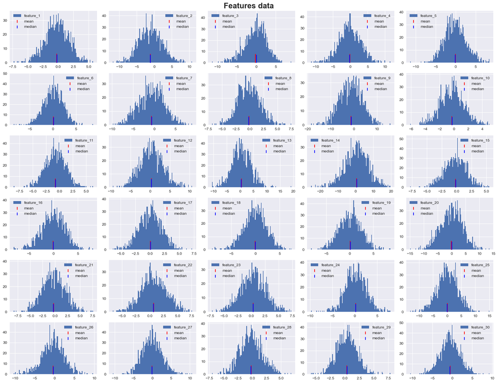

```python
plot_features(df)
```

The features do not have mean always equal to zero and the variance differs much among them.

For this reason, we proceed to create a train and test subsets of the data and we standardize it. We will see later if the standardization provides better accuracy on the test data.

#### **Create test data & standardiztion**

Now we split the dataset in train and test, shuffling the dataset beforehand and taking a stratified split, which preserves the proportions representative of the labels in the entire dataset. In this way, we have an accurate rapresentation of the data on which training our models and we do not risk misrepresentation of some characteristics.

```python
from sklearn.model_selection import train_test_split
from sklearn.preprocessing import StandardScaler
```

The following functions perform a scaling of the data in the same way, one with fitting on the data, the other one without fitting. This is to avoid data leakage on the test data.

```python
def fit_scaling(df: pd.DataFrame, ret=False) -> tuple[pd.DataFrame, StandardScaler] | pd.DataFrame:
    '''
    This function scales the features of the dataset. It takes a dataframe as input. It returns a scaled dataframe with the associated labels.
    If ret=True, it returns the StandardScaler object along with the scaled dataframe.
    '''
    sc = StandardScaler()
    df_scaled_np = sc.fit_transform(df[df.columns[1::]])
    df_scaled = pd.DataFrame(df_scaled_np, columns=df.columns[1::], index=df.index)

    # This makes sure the label column is the first one
    features = ['label']
    [features.append(i) for i in df.columns[1::]]
    df_scaled['label'] = df['label'].astype(np.int16)
    df_scaled = df_scaled[features]

    if ret:
        return df_scaled, sc
    else:
        return df_scaled


def nofit_scaling(df: pd.DataFrame, sc: StandardScaler) -> pd.DataFrame:
    '''
    This function scales the features of the dataset. It takes a dataframe and an already fitted StandardScaler object as input.
    It returns a scaled dataframe with the associated labels.
    '''
    df_scaled_np = sc.transform(df[df.columns[1::]])
    df_scaled = pd.DataFrame(df_scaled_np, columns=df.columns[1::], index=df.index)

    # This makes sure the label column is the first one
    features = ['label']
    [features.append(i) for i in df.columns[1::]]
    df_scaled['label'] = df['label'].astype(np.int16)
    df_scaled = df_scaled[features]

    return df_scaled
```

```python
df_train, df_test = train_test_split(df, test_size=0.2, random_state=7, shuffle=True, stratify=df[df.columns[0]])
```

```python
df_train
```

|  | label | feature_1 | feature_2 | feature_3 | feature_4 | feature_5 | feature_6 | feature_7 | feature_8 | feature_9 | ... | feature_21 | feature_22 | feature_23 | feature_24 | feature_25 | feature_26 | feature_27 | feature_28 | feature_29 | feature_30 |
| --- | --- | --- | --- | --- | --- | --- | --- | --- | --- | --- | --- | --- | --- | --- | --- | --- | --- | --- | --- | --- | --- |
| 104 | 0 | 3.102083 | -8.136695 | 2.358176 | -1.353544 | -1.780162 | -1.697023 | 1.856489 | -0.777038 | -8.071762 | ... | 0.559984 | -1.522353 | -0.337786 | -1.610009 | -4.386697 | -3.396144 | -0.253081 | -1.235948 | 2.071294 | -3.715494 |
| 967 | 3 | -0.420627 | -0.662856 | -3.740186 | -3.490542 | -5.526514 | -2.438404 | 1.964206 | -2.102574 | -4.736462 | ... | 0.636637 | 1.965218 | -1.569071 | -0.229285 | -0.812763 | 1.322398 | 2.210782 | -0.426918 | 1.742816 | -0.016905 |
| 1060 | 3 | 0.864300 | -3.618391 | 3.410593 | -1.289138 | 0.462411 | 0.059159 | -5.830729 | 1.560348 | 0.252643 | ... | -3.215897 | 2.488367 | 3.334405 | 1.550576 | -1.013309 | 1.959877 | -1.560938 | 1.242487 | 1.267401 | 1.423977 |
| 143 | 2 | -0.232301 | 0.860284 | -0.804784 | 5.812059 | 1.421958 | 0.724953 | -3.629323 | -1.587307 | 1.341180 | ... | 0.924001 | 2.226613 | 1.328515 | -1.876267 | 2.940881 | 0.705479 | 0.660935 | -1.910783 | 0.071208 | -3.819813 |
| 873 | 3 | -0.829288 | 5.306894 | 2.101648 | 0.947349 | 0.183059 | 0.197170 | 0.085015 | 1.896234 | 6.838270 | ... | -3.026023 | -3.296905 | 0.921808 | -1.115068 | 2.852222 | 5.287540 | -0.724985 | 1.921527 | -2.504538 | 4.982114 |
| ... | ... | ... | ... | ... | ... | ... | ... | ... | ... | ... | ... | ... | ... | ... | ... | ... | ... | ... | ... | ... | ... |
| 1179 | 3 | 2.060393 | 0.575221 | 1.514025 | 2.377877 | 3.484369 | -2.175540 | -4.543726 | -3.214164 | 2.065956 | ... | 0.411436 | 2.007315 | -2.809102 | 1.182370 | -0.951313 | 1.627299 | -2.272543 | -0.298542 | 0.080189 | -0.173717 |
| 983 | 3 | 0.934619 | -1.176920 | 2.755138 | 2.523941 | 1.690739 | -0.270440 | -0.946839 | 0.207916 | -2.093026 | ... | 0.221689 | -0.231894 | 0.686484 | 1.532901 | 2.099439 | 6.214966 | -3.700430 | 1.324688 | -1.402263 | 0.754082 |
| 1033 | 3 | 3.845521 | 0.731689 | -1.665133 | -0.692400 | -2.492798 | 1.967904 | 1.115227 | 1.223823 | 2.413275 | ... | 0.391523 | -2.066800 | 1.093044 | -2.601607 | 3.122193 | 3.112343 | 1.906273 | -1.825988 | -1.152089 | -0.613997 |
| 325 | 3 | -0.121748 | 2.251576 | -2.906889 | -1.412157 | 1.237988 | 1.062948 | -0.324138 | -2.984802 | 3.917601 | ... | -4.279616 | 2.134734 | 0.646201 | 3.763263 | 0.104280 | -0.682230 | 0.005665 | 0.444235 | -2.177072 | 2.086490 |
| 644 | 1 | -4.456768 | -0.054907 | -2.351456 | 5.615203 | -0.420196 | 1.871546 | -0.895563 | -0.273791 | -3.737989 | ... | 0.414571 | 0.099857 | -0.824161 | -1.314527 | 0.114282 | 0.649446 | -0.701938 | -3.263841 | -1.588114 | -1.793081 |

1040 rows × 31 columns

```python
df_train_scaled = fit_scaling(df_train)
df_train_scaled
```

|  | label | feature_1 | feature_2 | feature_3 | feature_4 | feature_5 | feature_6 | feature_7 | feature_8 | feature_9 | ... | feature_21 | feature_22 | feature_23 | feature_24 | feature_25 | feature_26 | feature_27 | feature_28 | feature_29 | feature_30 |
| --- | --- | --- | --- | --- | --- | --- | --- | --- | --- | --- | --- | --- | --- | --- | --- | --- | --- | --- | --- | --- | --- |
| 104 | 0 | 1.668215 | -2.153844 | 0.895869 | -0.413144 | -0.632586 | -0.841600 | 0.856691 | -0.300116 | -1.365193 | ... | 0.381931 | -0.964279 | -0.273686 | -0.760132 | -1.252468 | -1.101218 | -0.054375 | -0.531587 | 0.980476 | -1.280962 |
| 967 | 3 | -0.104342 | 0.110430 | -1.300957 | -1.083039 | -2.012524 | -1.192496 | 0.892036 | -0.954389 | -0.693671 | ... | 0.415699 | 0.532964 | -0.798908 | -0.186264 | -0.253524 | 0.593772 | 0.875603 | -0.116325 | 0.794531 | 0.214514 |
| 1060 | 3 | 0.542208 | -0.784978 | 1.274984 | -0.392954 | 0.193448 | -0.010399 | -1.665715 | 0.853597 | 0.310825 | ... | -1.281471 | 0.757556 | 1.292739 | 0.553496 | -0.309578 | 0.822767 | -0.548022 | 0.740552 | 0.525406 | 0.797116 |
| 143 | 2 | -0.009580 | 0.571881 | -0.243531 | 1.833092 | 0.546889 | 0.304722 | -0.943368 | -0.700058 | 0.529988 | ... | 0.542293 | 0.645183 | 0.437098 | -0.870796 | 0.795650 | 0.372164 | 0.290618 | -0.877968 | -0.151736 | -1.323142 |
| 873 | 3 | -0.309972 | 1.919025 | 0.803459 | 0.308129 | 0.090551 | 0.054922 | 0.275417 | 1.019388 | 1.636760 | ... | -1.197825 | -1.726109 | 0.263611 | -0.554421 | 0.770869 | 2.018127 | -0.232494 | 1.089092 | -1.609819 | 2.235802 |
| ... | ... | ... | ... | ... | ... | ... | ... | ... | ... | ... | ... | ... | ... | ... | ... | ... | ... | ... | ... | ... | ... |
| 1179 | 3 | 1.144058 | 0.485518 | 0.591779 | 0.756563 | 1.306561 | -1.068083 | -1.243411 | -1.503060 | 0.675913 | ... | 0.316490 | 0.551037 | -1.327860 | 0.400459 | -0.292250 | 0.703299 | -0.816615 | -0.050432 | -0.146652 | 0.151109 |
| 983 | 3 | 0.577591 | -0.045311 | 1.038867 | 0.802350 | 0.645892 | -0.166398 | -0.063165 | 0.186049 | -0.161447 | ... | 0.232901 | -0.410274 | 0.163231 | 0.546149 | 0.560460 | 2.351276 | -1.355567 | 0.782744 | -0.985841 | 0.526252 |
| 1033 | 3 | 2.042299 | 0.532922 | -0.553457 | -0.205892 | -0.895079 | 0.893011 | 0.613461 | 0.687491 | 0.745841 | ... | 0.307718 | -1.198014 | 0.336654 | -1.172268 | 0.846328 | 1.236755 | 0.760667 | -0.834444 | -0.844222 | -0.026913 |
| 325 | 3 | 0.046048 | 0.993386 | -1.000777 | -0.431517 | 0.479125 | 0.464696 | 0.141162 | -1.389849 | 1.048719 | ... | -1.750075 | 0.605739 | 0.146048 | 1.473150 | 0.002797 | -0.126328 | 0.043288 | 0.330823 | -1.424446 | 1.064994 |
| 644 | 1 | -2.135247 | 0.294614 | -0.800692 | 1.771383 | -0.131653 | 0.847405 | -0.046340 | -0.051718 | -0.492641 | ... | 0.317871 | -0.267851 | -0.481156 | -0.637321 | 0.005592 | 0.352035 | -0.223795 | -1.572470 | -1.091048 | -0.503660 |

1040 rows × 31 columns

#### **Plots**

Now we replot the features.

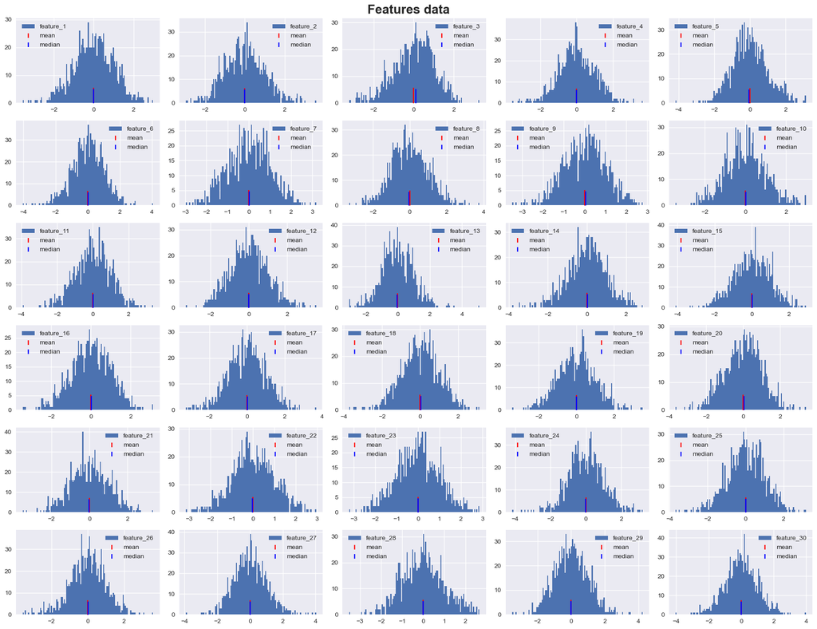

```python
plot_features(df_train_scaled)
```

At this point we see that the variance is uniform for every feature. Moreover, the mean is always equal to zero and the median overlaps with it, suggesting symmetry in the distribution (a statistical test would be useful to actually validate it, but from the histogram we see that the data is pretty much normally distributed).

We also perform another kind of plot, which lets us see the impact of the StandardScaler on the data better.

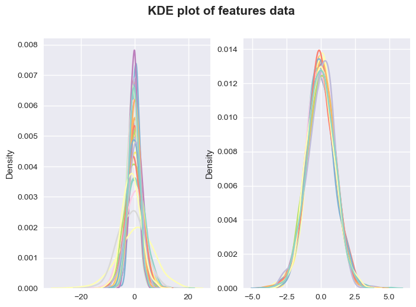

```python
fig, ax = plt.subplots(1,2)
plt.suptitle('KDE plot of features data', fontsize=15, fontweight='bold')
sns.kdeplot(data=df[df.columns[1::]], palette = "Set3", bw_adjust = 1.2, legend=False, ax=ax[0])
sns.kdeplot(data=df_train_scaled[df_train_scaled.columns[1::]], palette = "Set3", bw_adjust = 1.2, legend=False, ax=ax[1])
plt.show()
```

We can see that now all the features follow a similar distribution, with similar density for every realization of X (if seen as a random variable).

Now we want to plot the correlation coefficients of the features against every other feature to check whether some are highly correlated with each other. If it is the case, we may consider substituting them with one of their combination, so to reduce redundancy and multicollinearity. Then, we will plot a restrited version of the correlation matrix, with only the target label as covariate on one axis.

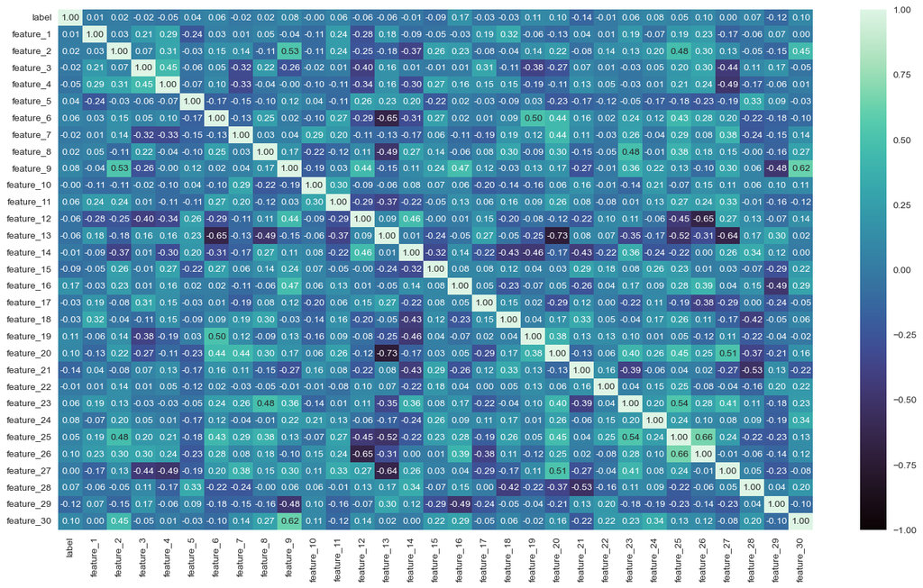

```python
plt.figure(figsize = (18,10))
sns.heatmap(df_train_scaled.corr(), cmap = 'mako', annot = True, vmin=-1, vmax=1, fmt = '.2f')
```

We can see that there is little correlation between most features, with some exceptions exposing either negative or positive correlations up to ~0.7 in absolute value, making us discard the hypothesis of opting for a combination of features instead of the current configuration.

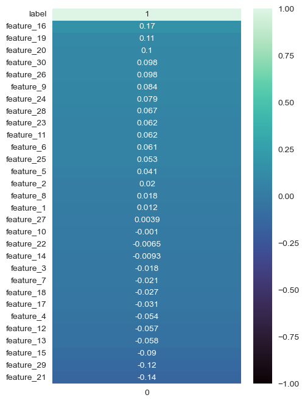

```python
plt.figure(figsize = (5,8))
sns.heatmap(df_train_scaled.corrwith(df_train_scaled['label']).sort_values(ascending = False).to_frame(), cmap = 'mako', annot = True, vmin=-1, vmax=1)
```

Unfortunately, we can say that no feature is highly correlated with the label.

### Data Visualization

Now we proceed to plot the data with PCA in order to have a grasp of their geometric structure (e.g. linear separability among classes).

Since PCA is susceptible to the scale of the data, we perform it on the scaled Dataset.

```python
from sklearn.decomposition import PCA
```

```python
df_train_scaled
```

|  | label | feature_1 | feature_2 | feature_3 | feature_4 | feature_5 | feature_6 | feature_7 | feature_8 | feature_9 | ... | feature_21 | feature_22 | feature_23 | feature_24 | feature_25 | feature_26 | feature_27 | feature_28 | feature_29 | feature_30 |
| --- | --- | --- | --- | --- | --- | --- | --- | --- | --- | --- | --- | --- | --- | --- | --- | --- | --- | --- | --- | --- | --- |
| 104 | 0 | 1.668215 | -2.153844 | 0.895869 | -0.413144 | -0.632586 | -0.841600 | 0.856691 | -0.300116 | -1.365193 | ... | 0.381931 | -0.964279 | -0.273686 | -0.760132 | -1.252468 | -1.101218 | -0.054375 | -0.531587 | 0.980476 | -1.280962 |
| 967 | 3 | -0.104342 | 0.110430 | -1.300957 | -1.083039 | -2.012524 | -1.192496 | 0.892036 | -0.954389 | -0.693671 | ... | 0.415699 | 0.532964 | -0.798908 | -0.186264 | -0.253524 | 0.593772 | 0.875603 | -0.116325 | 0.794531 | 0.214514 |
| 1060 | 3 | 0.542208 | -0.784978 | 1.274984 | -0.392954 | 0.193448 | -0.010399 | -1.665715 | 0.853597 | 0.310825 | ... | -1.281471 | 0.757556 | 1.292739 | 0.553496 | -0.309578 | 0.822767 | -0.548022 | 0.740552 | 0.525406 | 0.797116 |
| 143 | 2 | -0.009580 | 0.571881 | -0.243531 | 1.833092 | 0.546889 | 0.304722 | -0.943368 | -0.700058 | 0.529988 | ... | 0.542293 | 0.645183 | 0.437098 | -0.870796 | 0.795650 | 0.372164 | 0.290618 | -0.877968 | -0.151736 | -1.323142 |
| 873 | 3 | -0.309972 | 1.919025 | 0.803459 | 0.308129 | 0.090551 | 0.054922 | 0.275417 | 1.019388 | 1.636760 | ... | -1.197825 | -1.726109 | 0.263611 | -0.554421 | 0.770869 | 2.018127 | -0.232494 | 1.089092 | -1.609819 | 2.235802 |
| ... | ... | ... | ... | ... | ... | ... | ... | ... | ... | ... | ... | ... | ... | ... | ... | ... | ... | ... | ... | ... | ... |
| 1179 | 3 | 1.144058 | 0.485518 | 0.591779 | 0.756563 | 1.306561 | -1.068083 | -1.243411 | -1.503060 | 0.675913 | ... | 0.316490 | 0.551037 | -1.327860 | 0.400459 | -0.292250 | 0.703299 | -0.816615 | -0.050432 | -0.146652 | 0.151109 |
| 983 | 3 | 0.577591 | -0.045311 | 1.038867 | 0.802350 | 0.645892 | -0.166398 | -0.063165 | 0.186049 | -0.161447 | ... | 0.232901 | -0.410274 | 0.163231 | 0.546149 | 0.560460 | 2.351276 | -1.355567 | 0.782744 | -0.985841 | 0.526252 |
| 1033 | 3 | 2.042299 | 0.532922 | -0.553457 | -0.205892 | -0.895079 | 0.893011 | 0.613461 | 0.687491 | 0.745841 | ... | 0.307718 | -1.198014 | 0.336654 | -1.172268 | 0.846328 | 1.236755 | 0.760667 | -0.834444 | -0.844222 | -0.026913 |
| 325 | 3 | 0.046048 | 0.993386 | -1.000777 | -0.431517 | 0.479125 | 0.464696 | 0.141162 | -1.389849 | 1.048719 | ... | -1.750075 | 0.605739 | 0.146048 | 1.473150 | 0.002797 | -0.126328 | 0.043288 | 0.330823 | -1.424446 | 1.064994 |
| 644 | 1 | -2.135247 | 0.294614 | -0.800692 | 1.771383 | -0.131653 | 0.847405 | -0.046340 | -0.051718 | -0.492641 | ... | 0.317871 | -0.267851 | -0.481156 | -0.637321 | 0.005592 | 0.352035 | -0.223795 | -1.572470 | -1.091048 | -0.503660 |

1040 rows × 31 columns

As before, we define some useful functions for variable-scope reasons.

```python
def make_pca_tranform(df: pd.DataFrame, n_components: int) -> tuple[PCA, np.ndarray]:
    '''
        The function below makes a PCA transformation of the dataset. It takes a dataframe and the number of components as input.
    '''

    pca = PCA(n_components=n_components, random_state=7)
    df_pca_np = pca.fit_transform(df)
    print(df_pca_np.shape)

    if n_components > 1:
        return pca, df_pca_np
    else:
        return df_pca_np


def plots_pca_max_components(fitted_pca: PCA, df: pd.DataFrame) -> None:
    '''
        The function below plots the explained variance ratio of the principal components. It takes a fitted PCA object and a dataframe as input.
    '''

    cumsum = np.cumsum(fitted_pca.explained_variance_ratio_)

    fig, ax = plt.subplots(1, 2)
    fig.set_size_inches(18, 8)
    ax[0].plot(np.append(np.array([0]), cumsum), linewidth = 3)
    ax[0].set_xlabel("Dimensions")
    ax[0].set_ylabel("Explained Variance")
    ax[0].set_title('Explained Variance vs Number of Principal Components', fontweight='bold')

    labels = [str(i+1) for i in range(len(fitted_pca.explained_variance_ratio_))]
    ax[1].bar(labels, fitted_pca.explained_variance_ratio_)
    ax[1].set_xlabel('Principal Components')
    ax[1].set_ylabel('Variance Explained')
    ax[1].set_title('Proportion of Variance Explained by the Principal Components', fontweight='bold')

    plt.tight_layout()
    plt.show()
```

```
(1040, 30)
```

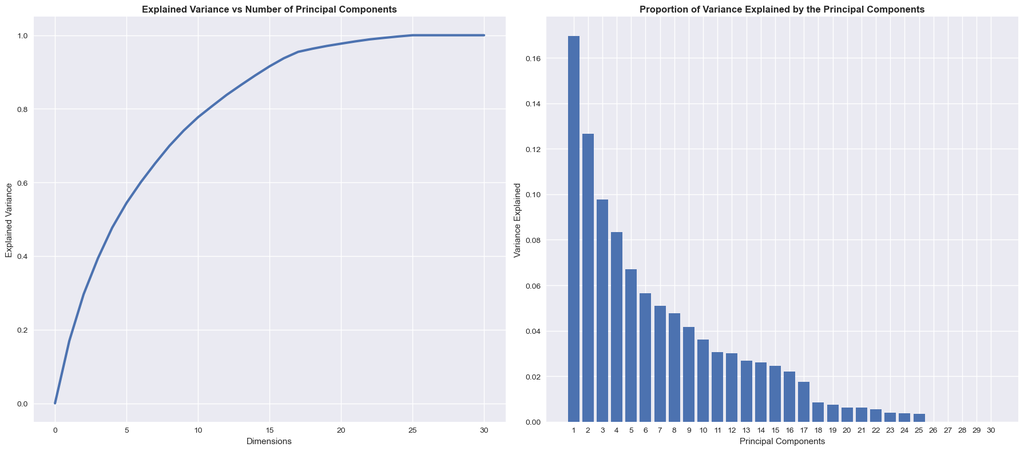

```python
plots_pca_max_components(*make_pca_tranform(df_train_scaled[df_train_scaled.columns[1:]], df_train_scaled.shape[1]-1))
```

There is no clear elbow here. Also, all components, when taken singularly, contribute to less than 20% of the explained variance. However, we see that the last components cumulatively contribute to explain 0% of the variance. Thus, We decide to proceed to get the components that result in a 95% variance (euristically) explained in the dataset, in order to figure out if actually PCA can be efficiently applied to this dataset (even for classification purposes).

```python
def plot_pca_given_components(df_pca_np: np.ndarray, df: pd.DataFrame) -> None:
    '''
    This function plots the PCA in 2D and 3D. It takes a PCA Numpy array and the original dataframe as input.
    '''

    fig, ax = plt.subplots(1, 2, figsize=(12, 5))
    ax[0].scatter(df_pca_np[::1, 0], df_pca_np[::1, 1], c=df[df.columns[0]], cmap='Accent', alpha=0.9, s=10)
    ax[0].set_title('2D PCA')
    ax[1] = fig.add_subplot(1, 2, 2, projection='3d')
    ax[1].scatter(df_pca_np[::1, 0], df_pca_np[::1, 1], df_pca_np[::1, 2], c=df[df.columns[0]], cmap='Accent', alpha=0.9, s=10)
    ax[1].set_title('3D PCA')
    plt.show()

def pca_to_pd(df_pca_np: np.ndarray) -> pd.DataFrame:
    '''
    This function creates a DataFrame starting from the PCA Numpy array. It takes a PCA Numpy array as input.
    '''

    col = ['PCA'+str(i+1) for i in range(df_pca_np.shape[1])]
    df_pca = pd.DataFrame(df_pca_np, columns=col)

    # This makes sure the label column is the first one
    features = ['label']
    [features.append(i) for i in col]
    df_pca['label'] = df['label']
    df_pca = df_pca[features]

    return df_pca
```

```python
df_train_pca_np = make_pca_tranform(df_train_scaled[df_train_scaled.columns[1:]], 0.95)
df_train_pca = pca_to_pd(df_train_pca_np)
```

```
(1040, 17)
```

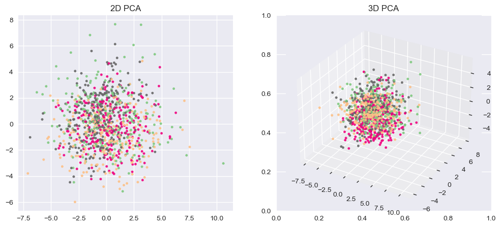

```python
plot_pca_given_components(df_train_pca_np, df_train)
```

From the plots we see that data are highly nonseparable with an affine hyperplane. This most likely implies that our models (linear) will not perform well.

17 features are enough to explain 95% of the variance. This might be used for classification purposes in some cases, since giving to a model a more compact representation of the data makes it less prone to overfitting and, usually, more generalizable. For the purpose of this notebook, we will not pursue this.

### UMAP (Extra)

Now we want to visualize the data with another tool: UMAP. It performs nonlinear transformations of the features to project the data in a lower-dimensional space. It relies on some manifold assumption, but is largely applicable for many datasets.

```python
'''
    if you did not install umap-learn, you should run:
        conda install -c conda-forge umap-learn
    or:
        pip install umap-learn
'''
```

```python
import umap
```

```python
def make_umap_tranforms(df: pd.DataFrame) -> tuple[np.ndarray]:
    '''
    This function creates 2D and 3D representations of the data using UMAP. It takes a dataframe as input.
    '''

    # UMAP 2D
    map_umap2 = umap.UMAP(n_components=2, random_state=7, n_jobs=1) # n_jobs=-1 is overriden if random_state is set
    transformed_df2 = map_umap2.fit_transform(df[df.columns[1:]])

    # UMAP 3D
    map_umap3 = umap.UMAP(n_components=3, random_state=7, n_jobs=1) # n_jobs=-1 is overriden if random_state is set
    transformed_df3 = map_umap3.fit_transform(df[df.columns[1:]])

    return transformed_df2, transformed_df3

def plot_umap(array2d: np.ndarray, array3d: np.ndarray, labels: np.ndarray | pd.Series) -> None:
    '''
    This function plots the UMAP in 2D and in 3D. It takes the 2 arrays of the UMAP transformation and the labels as input.
    '''

    fig = plt.figure(figsize=(12, 5))
    ax1 = fig.add_subplot(121)
    ax1.scatter(array2d[::, 0], array2d[::, 1], c=labels, cmap='Accent', s=10)
    ax1.set_title('UMAP 2D')
    ax2 = fig.add_subplot(122, projection='3d')
    ax2.scatter(array3d[::, 0], array3d[::, 1], array3d[::, 2], c=labels, cmap='Accent', s=10)
    ax2.set_title('UMAP 3D')

    plt.suptitle('UMAP', fontsize=15, fontweight='bold')
    plt.show()
```

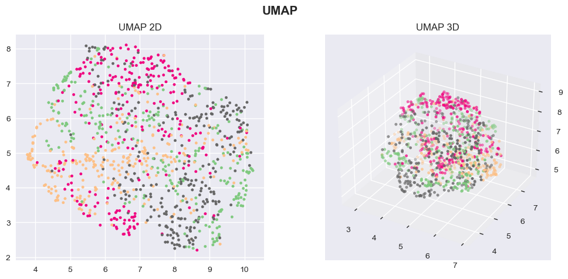

```python
plot_umap(*make_umap_tranforms(df_train_scaled), df_train_scaled[df_train_scaled.columns[0]])
```

Here we can see that even UMAP fails to correctly separate the dataset. This suggests that the data is very noisy and the classification will most likely not perform well, especially if we just use linear models.

## Classification

### Initialization

```python
df_train.describe()
```

|  | label | feature_1 | feature_2 | feature_3 | feature_4 | feature_5 | feature_6 | feature_7 | feature_8 | feature_9 | ... | feature_21 | feature_22 | feature_23 | feature_24 | feature_25 | feature_26 | feature_27 | feature_28 | feature_29 | feature_30 |
| --- | --- | --- | --- | --- | --- | --- | --- | --- | --- | --- | --- | --- | --- | --- | --- | --- | --- | --- | --- | --- | --- |
| count | 1040.000000 | 1040.000000 | 1040.000000 | 1040.000000 | 1040.000000 | 1040.000000 | 1040.000000 | 1040.000000 | 1040.000000 | 1040.000000 | ... | 1040.000000 | 1040.000000 | 1040.000000 | 1040.000000 | 1040.000000 | 1040.000000 | 1040.000000 | 1040.000000 | 1040.000000 | 1040.000000 |
| mean | 1.528846 | -0.213262 | -1.027360 | -0.128745 | -0.035596 | -0.062774 | 0.081129 | -0.754340 | -0.169013 | -1.291153 | ... | -0.306989 | 0.723770 | 0.303820 | 0.218867 | 0.094273 | -0.330556 | -0.109021 | -0.200288 | 0.339255 | -0.547437 |
| std | 1.126774 | 1.988316 | 3.302355 | 2.777323 | 3.191584 | 2.716176 | 2.113839 | 3.049040 | 2.026943 | 4.969167 | ... | 2.271067 | 2.330449 | 2.345442 | 2.407155 | 3.579434 | 2.785156 | 2.650653 | 1.949180 | 1.767379 | 2.474375 |
| min | 0.000000 | -7.288856 | -10.794725 | -9.078218 | -11.328164 | -11.377089 | -8.468697 | -9.811625 | -6.819311 | -18.529887 | ... | -8.285467 | -6.626036 | -7.229772 | -9.789430 | -13.111577 | -10.325207 | -10.493101 | -7.048643 | -5.843082 | -10.543714 |
| 25% | 1.000000 | -1.500565 | -3.344104 | -1.866338 | -2.011816 | -1.878651 | -1.169799 | -2.870424 | -1.588529 | -4.671219 | ... | -1.834236 | -0.801901 | -1.302335 | -1.319275 | -2.139092 | -2.039607 | -1.842872 | -1.570444 | -0.853475 | -2.146964 |
| 50% | 2.000000 | -0.199558 | -1.055638 | 0.139164 | -0.108126 | -0.185625 | 0.145709 | -0.660537 | -0.234359 | -1.056958 | ... | -0.348856 | 0.637794 | 0.314810 | 0.214638 | 0.088365 | -0.245875 | -0.119049 | -0.223458 | 0.339571 | -0.567959 |
| 75% | 3.000000 | 1.150621 | 1.133750 | 1.817298 | 2.049212 | 1.655489 | 1.556818 | 1.416831 | 1.125844 | 2.072866 | ... | 1.209255 | 2.286994 | 1.911685 | 1.745646 | 2.540969 | 1.579560 | 1.610065 | 1.060673 | 1.499702 | 1.056993 |
| max | 3.000000 | 5.704117 | 10.787729 | 8.965615 | 11.534110 | 8.444147 | 8.654119 | 8.966401 | 7.470686 | 12.530644 | ... | 7.269089 | 7.627682 | 7.023339 | 7.950010 | 11.452113 | 9.701695 | 10.591150 | 4.997543 | 7.852934 | 9.296404 |

8 rows × 31 columns

```python
df_train_scaled.describe()
```

|  | label | feature_1 | feature_2 | feature_3 | feature_4 | feature_5 | feature_6 | feature_7 | feature_8 | feature_9 | ... | feature_21 | feature_22 | feature_23 | feature_24 | feature_25 | feature_26 | feature_27 | feature_28 | feature_29 | feature_30 |
| --- | --- | --- | --- | --- | --- | --- | --- | --- | --- | --- | --- | --- | --- | --- | --- | --- | --- | --- | --- | --- | --- |
| count | 1040.000000 | 1.040000e+03 | 1.040000e+03 | 1.040000e+03 | 1.040000e+03 | 1.040000e+03 | 1.040000e+03 | 1.040000e+03 | 1.040000e+03 | 1040.000000 | ... | 1.040000e+03 | 1.040000e+03 | 1040.000000 | 1.040000e+03 | 1.040000e+03 | 1.040000e+03 | 1.040000e+03 | 1.040000e+03 | 1.040000e+03 | 1.040000e+03 |
| mean | 1.528846 | -1.878839e-17 | 5.807320e-17 | 1.195625e-17 | -1.024821e-17 | -1.366428e-17 | 2.562053e-17 | 3.074464e-17 | -8.540177e-19 | 0.000000 | ... | -1.708035e-17 | -3.074464e-17 | 0.000000 | 2.732857e-17 | 1.537232e-17 | -2.220446e-17 | -5.124106e-18 | -7.686159e-18 | -2.476651e-17 | -3.416071e-18 |
| std | 1.126774 | 1.000481e+00 | 1.000481e+00 | 1.000481e+00 | 1.000481e+00 | 1.000481e+00 | 1.000481e+00 | 1.000481e+00 | 1.000481e+00 | 1.000481 | ... | 1.000481e+00 | 1.000481e+00 | 1.000481 | 1.000481e+00 | 1.000481e+00 | 1.000481e+00 | 1.000481e+00 | 1.000481e+00 | 1.000481e+00 | 1.000481e+00 |
| min | 0.000000 | -3.560298e+00 | -2.959120e+00 | -3.223888e+00 | -3.539936e+00 | -4.167535e+00 | -4.046638e+00 | -2.971966e+00 | -3.282529e+00 | -3.470809 | ... | -3.514787e+00 | -3.155332e+00 | -3.213559 | -4.159728e+00 | -3.691144e+00 | -3.590269e+00 | -3.919440e+00 | -3.515146e+00 | -3.499707e+00 | -4.041863e+00 |
| 25% | 1.000000 | -6.477449e-01 | -7.018806e-01 | -6.259370e-01 | -6.194954e-01 | -6.688632e-01 | -5.920652e-01 | -6.943506e-01 | -7.006608e-01 | -0.680535 | ... | -6.728034e-01 | -6.549829e-01 | -0.685128 | -6.392948e-01 | -6.242438e-01 | -6.139237e-01 | -6.544372e-01 | -7.032779e-01 | -6.751824e-01 | -6.467478e-01 |
| 50% | 2.000000 | 6.895952e-03 | -8.567066e-03 | 9.650945e-02 | -2.273642e-02 | -4.525115e-02 | 3.056549e-02 | 3.077952e-02 | -3.225445e-02 | 0.047152 | ... | -1.844357e-02 | -3.691000e-02 | 0.004688 | -1.757779e-03 | -1.651405e-03 | 3.041910e-02 | -3.785162e-03 | -1.189282e-02 | 1.791295e-04 | -8.297611e-03 |
| 75% | 3.000000 | 6.862791e-01 | 6.547300e-01 | 7.010272e-01 | 6.535347e-01 | 6.329083e-01 | 6.984446e-01 | 7.124260e-01 | 6.391298e-01 | 0.677304 | ... | 6.679567e-01 | 6.711050e-01 | 0.685857 | 6.345722e-01 | 6.838717e-01 | 6.861499e-01 | 6.488638e-01 | 6.472300e-01 | 6.569084e-01 | 6.487304e-01 |
| max | 3.000000 | 2.977508e+00 | 3.579499e+00 | 3.276081e+00 | 3.626811e+00 | 3.133455e+00 | 4.057601e+00 | 3.189666e+00 | 3.770888e+00 | 2.782850 | ... | 3.337516e+00 | 2.963906e+00 | 2.866305 | 3.213279e+00 | 3.174609e+00 | 3.603776e+00 | 4.038748e+00 | 2.667959e+00 | 4.253357e+00 | 3.980228e+00 |

8 rows × 31 columns

First, we import the necessary libraries to perform our classification.

```python
from sklearn.linear_model import LogisticRegression
from sklearn.svm import LinearSVC
from sklearn.model_selection import GridSearchCV
from sklearn.metrics import accuracy_score, confusion_matrix, classification_report
```

We split X and y in the raw dataset and in the scaled one.

```python
X_train, y_train = df_train[df_train.columns[1::]], df_train['label']
X_test, y_test = df_test[df_test.columns[1::]], df_test['label']

df_train_scaled, scaler = fit_scaling(df_train, ret=True)
df_test_scaled = nofit_scaling(df_test, scaler) # We use the same scaler for both the training and test set, fitting it only on the training set.

X_train_scaled, y_train_scaled = df_train_scaled[df_train_scaled.columns[1::]], df_train_scaled['label']
X_test_scaled, y_test_scaled = df_test_scaled[df_train_scaled.columns[1::]], df_test_scaled['label']

data_tot = (X_train, X_test, y_train, y_test)
data_tot_scaled = (X_train_scaled, X_test_scaled, y_train_scaled, y_test_scaled)
```

Here we define some functions that we will use later, in order to keep the code cleaner. They define the model, perform Gridsearch on it in a clever way, and print scores and confusion matrices.

We are aware that the result that we will get from GridSearch is not the real optimal one, since especially for float-type parameters, it is not possible to explore all feasible values. Instead, we aim at optimizing the performance given the time complexity of the algorithm. For this reason, we check the result for just a couple of values which are representative of a neighborhood around them, for instance: $C = [0.1, 1.0, 10.0]$ as possible choices of the regularization parameter for LinearSVC.

```python
def logistic(penalty='l2', C=1.0, solver='lbfgs', multi_class='multinomial', l1_ratio=None, n_jobs=-1) -> LogisticRegression:
    '''
    This function builds a logistic regression model. It takes the following parameters as input: penalty, C, solver, multi_class, l1_ratio, n_jobs.
    '''

    model = LogisticRegression(max_iter=10000, random_state=7, penalty=penalty, C=C, fit_intercept=True,
                                solver=solver, multi_class=multi_class, l1_ratio=l1_ratio, n_jobs=n_jobs, verbose=0)

    return model


def grid_logistic(x: pd.DataFrame, y: pd.DataFrame) -> tuple[float, dict]:
    '''
    This function performs a grid search for the logistic regression model. It takes the training data as input.
    '''

    # Here the choice of parameters is based on the fact that some solvers do not support some penalties, parallel computing (n_jobs>1), or multi_class options.
    params_set=[
        # penalty l1
        {'penalty': ['l1'], 'C': [0.1, 1.0, 10.0], 'solver': ['saga'], 'multi_class': ['multinomial', 'ovr'], 'n_jobs': [-1]},
        {'penalty': ['l1'], 'C': [0.1, 1.0, 10.0], 'solver': ['liblinear'], 'multi_class': ['ovr'], 'n_jobs': [1]},
        # penalty l2
        {'penalty': ['l2'], 'C': [0.1, 1.0, 10.0], 'solver': ['lbfgs', 'newton-cg', 'sag', 'saga'], 'multi_class': ['ovr', 'multinomial'], 'n_jobs': [-1]},
        {'penalty': ['l2'], 'C': [0.1, 1.0, 10.0], 'solver': ['liblinear'], 'multi_class': ['ovr'], 'n_jobs': [1]},
        # penalty elasticnet
        {'penalty': ['elasticnet'], 'C': [0.1, 1.0, 10.0], 'solver': ['saga'], 'multi_class': ['ovr', 'multinomial'], 'l1_ratio': [0.1, 0.5, 0.9], 'n_jobs': [-1]},
    ]

    GS_logi = GridSearchCV(logistic(), cv=5, param_grid=params_set, scoring='accuracy', verbose=1, n_jobs=-1)
    params_logi = GS_logi.fit(x, y).best_params_

    print(f'Best score : {GS_logi.best_score_}, \nObtained with parameters: {params_logi}')

    return GS_logi.best_score_, params_logi
```

```python
def linearsvm(penalty='l2', loss='squared_hinge', C=1.0, multi_class='ovr', class_weight=None) -> LinearSVC:
    '''
    This function builds a linear SVM model. It takes the following parameters as input: penalty, loss, C, multi_class, class_weight.
    Since the problem is ill-conditioned in this notebook's case (there is no clear separation between classes),
    a higher maximum number of iterations is set in order to allow the model to converge.
    Also, class_frequencies are balanced by default, but can be set according to the proportion of the classes in the dataset.
    '''

    model = LinearSVC(max_iter=1000000, random_state=7, penalty=penalty, loss=loss, C=C, multi_class=multi_class, class_weight=class_weight, dual='auto')

    return model


def grid_svm(x: pd.DataFrame, y: pd.DataFrame) -> tuple[float, dict]:
    '''
    This function performs a grid search for the linear SVM model. It takes the training data as input.
    '''

    params_set = [
        {'penalty': ['l2'], 'loss': ['hinge', 'squared_hinge'], 'C': [0.1, 1.0, 10.0], 'multi_class': ['ovr', 'crammer_singer']},
        # With l1 penalty, hinge loss is not supported
        {'penalty': ['l1'], 'loss': ['squared_hinge'], 'C': [0.1, 1.0, 10.0], 'multi_class': ['ovr', 'crammer_singer']}
    ]

    GS_svm = GridSearchCV(linearsvm(class_weight=class_frequencies), cv=5, param_grid=params_set, scoring='accuracy', verbose=1, n_jobs=-1) # class_weight=class_frequencies
    params_svc = GS_svm.fit(x, y).best_params_

    print(f'Best score : {GS_svm.best_score_}, \nObtained with parameters: {params_svc}')

    return GS_svm.best_score_, params_svc
```

```python
def print_score(model: LinearSVC | LogisticRegression, data: list[pd.DataFrame]) -> np.ndarray:
    '''
    This function computes and plots the confusion matrix for the given model on the data provided. It takes the model and the data as input.
    '''

    model.fit(data[0], data[2])
    y_pred = model.predict(data[1])
    print(f'Accuracy on test: {round(accuracy_score(data[3], y_pred), 4)}')
    s = sns.heatmap(confusion_matrix(data[3], y_pred, normalize='true', labels=[0, 1, 2, 3]), annot=True, fmt='.2f', cmap='mako', vmin=0, vmax=1, ax=plt.gca())
    s.set(xlabel='Predicted label', ylabel='Actual label')
    plt.grid(False)

    return y_pred
```

### Raw dataset

#### **Logistic**

```python
kfold_score_logi, params_logi = grid_logistic(X_train, y_train)

# running time: ~ 15 seconds
```

```
Fitting 5 folds for each of 54 candidates, totalling 270 fits
Best score : 0.5673076923076923,
Obtained with parameters: {'C': 1.0, 'multi_class': 'ovr', 'n_jobs': 1, 'penalty': 'l1', 'solver': 'liblinear'}
```

```
Accuracy on test: 0.5769
              precision    recall  f1-score   support

           0       0.52      0.52      0.52        63
           1       0.64      0.65      0.64        65
           2       0.66      0.60      0.63        63
           3       0.51      0.54      0.52        69

    accuracy                           0.58       260
   macro avg       0.58      0.58      0.58       260
weighted avg       0.58      0.58      0.58       260
```

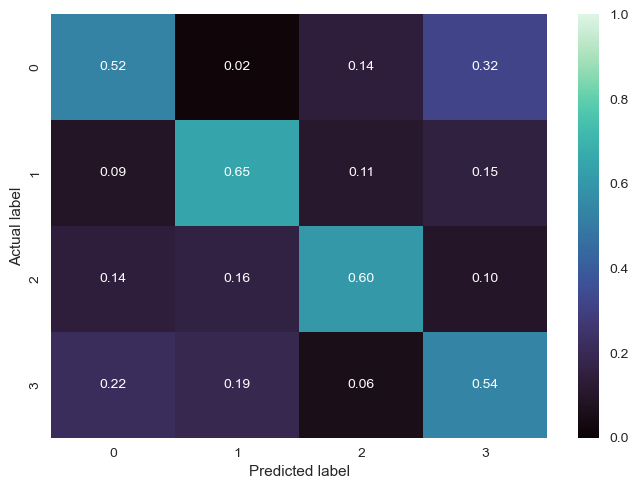

```python
logistic_model = logistic(**params_logi)
res_logi = print_score(logistic_model, data_tot)
print(classification_report(y_test, res_logi))
```

#### **LinearSVC**

```python
kfold_score_svc, params_svc = grid_svm(X_train, y_train)

# running time: ~ 20s
```

```
Fitting 5 folds for each of 18 candidates, totalling 90 fits
```

```
Best score : 0.5625,
Obtained with parameters: {'C': 10.0, 'loss': 'hinge', 'multi_class': 'crammer_singer', 'penalty': 'l2'}
```

```
Accuracy on test: 0.6077
              precision    recall  f1-score   support

           0       0.58      0.49      0.53        63
           1       0.66      0.65      0.65        65
           2       0.65      0.67      0.66        63
           3       0.55      0.62      0.59        69

    accuracy                           0.61       260
   macro avg       0.61      0.61      0.61       260
weighted avg       0.61      0.61      0.61       260
```

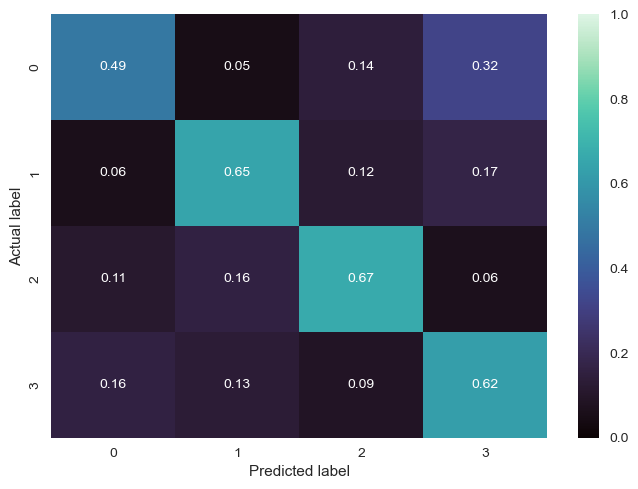

```python
svc_model = linearsvm(**params_svc)
res_svc = print_score(svc_model, data_tot)
print(classification_report(y_test, res_svc))
```

In the raw Dataset, LinearSVC performs slightly better.

### Scaled Dataset

#### **Logistic**

```python
kfold_score_logi_scaled, params_logi_scaled = grid_logistic(X_train_scaled, y_train_scaled)

# running time: ~ 10 seconds
```

```
Fitting 5 folds for each of 54 candidates, totalling 270 fits
Best score : 0.5673076923076923,
Obtained with parameters: {'C': 1.0, 'l1_ratio': 0.5, 'multi_class': 'ovr', 'n_jobs': -1, 'penalty': 'elasticnet', 'solver': 'saga'}
```

```
Accuracy on test: 0.5769
              precision    recall  f1-score   support

           0       0.52      0.52      0.52        63
           1       0.63      0.65      0.64        65
           2       0.66      0.60      0.63        63
           3       0.51      0.54      0.52        69

    accuracy                           0.58       260
   macro avg       0.58      0.58      0.58       260
weighted avg       0.58      0.58      0.58       260
```

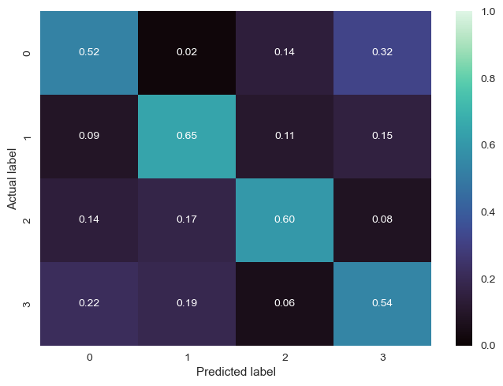

```python
logistic_model_scaled = logistic(**params_logi_scaled)
res_logi_scaled = print_score(logistic_model_scaled, data_tot_scaled)
print(classification_report(y_test_scaled, res_logi_scaled))
```

#### **LinearSVC**

```python
kfold_score_svc_scaled, params_svc_scaled = grid_svm(X_train_scaled, y_train_scaled)

# running time: ~ 10s
```

```
Fitting 5 folds for each of 18 candidates, totalling 90 fits
Best score : 0.5596153846153846,
Obtained with parameters: {'C': 1.0, 'loss': 'squared_hinge', 'multi_class': 'ovr', 'penalty': 'l1'}
```

```
Accuracy on test: 0.5885
              precision    recall  f1-score   support

           0       0.56      0.51      0.53        63
           1       0.62      0.66      0.64        65
           2       0.67      0.63      0.65        63
           3       0.51      0.55      0.53        69

    accuracy                           0.59       260
   macro avg       0.59      0.59      0.59       260
weighted avg       0.59      0.59      0.59       260
```

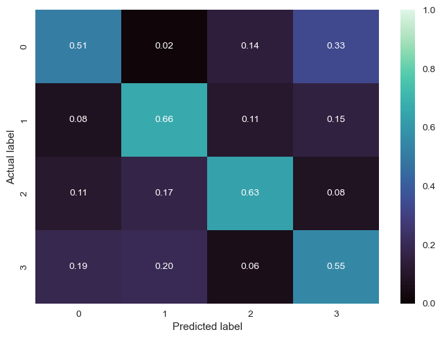

```python
svc_model_scaled = linearsvm(**params_svc_scaled)
res_svc_scaled = print_score(svc_model_scaled, data_tot_scaled)
print(classification_report(y_test_scaled, res_svc_scaled))
```

In the scaled Dataset, LinearSVC performs worse, while LogisticRegression has the same results. In this dataset they are comparable.

### SVM with kernel (Extra)

We implement a nonlinear SVM model using a kernel. We want to see how much difference in accuracy there is by allowing a model for nonlinear transformation of the dataset. We expect the accuracy to increase, as the dataset is not linearly separable.

```python
from sklearn.svm import SVC
```

```python
def grid_ksvm(x: pd.DataFrame, y: pd.DataFrame) -> tuple[float, dict]:
    '''
    This function performs a grid search for the SVM model with kernel. It takes the training data as input.
    '''

    params_set = [
            {'C': [0.1, 1.0, 10.0], 'gamma': ['scale', 'auto'], 'kernel': ['linear', 'rbf', 'sigmoid'],
            'class_weight': [class_frequencies], 'decision_function_shape': ['ovo', 'ovr']},

            {'C': [0.1, 1.0, 10.0], 'gamma': ['scale', 'auto'], 'kernel': ['poly'], 'degree': [2, 3, 4],
            'class_weight': [class_frequencies], 'decision_function_shape': ['ovo', 'ovr']},
        ]

    GS_ksvm = GridSearchCV(SVC(random_state=7), cv=5, param_grid=params_set, scoring='accuracy', n_jobs=-1, verbose=1)
    params_ksvc = GS_ksvm.fit(x, y).best_params_

    print(f'Best score : {GS_ksvm.best_score_}, \nObtained with parameters: {params_ksvc}')

    return GS_ksvm.best_score_, params_ksvc
```

#### Raw Dataset

```python
kfold_score_ksvc, params_ksvc = grid_ksvm(X_train, y_train)

# running time: ~ 5s
```

```
Fitting 5 folds for each of 72 candidates, totalling 360 fits
Best score : 0.801923076923077,
Obtained with parameters: {'C': 10.0, 'class_weight': {0: 0.244, 1: 0.248, 2: 0.242, 3: 0.265}, 'decision_function_shape': 'ovo', 'gamma': 'scale', 'kernel': 'rbf'}
```

[output not shown]

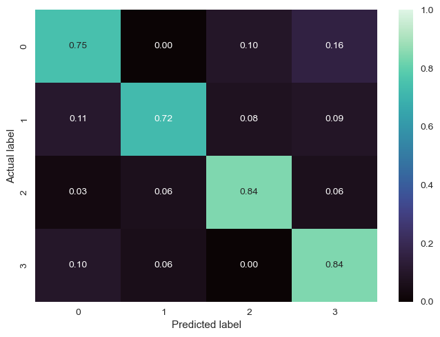

```python
ksvc_model = SVC(**params_ksvc)
res_ksvc = print_score(ksvc_model, data_tot)
print(classification_report(y_test, res_ksvc))
```

#### Scaled Dataset

```python
kfold_score_ksvc_scaled, params_ksvc_scaled = grid_ksvm(X_train_scaled, y_train_scaled)

# running time: ~ 5s
```

```
Fitting 5 folds for each of 72 candidates, totalling 360 fits
Best score : 0.8259615384615385,
Obtained with parameters: {'C': 10.0, 'class_weight': {0: 0.244, 1: 0.248, 2: 0.242, 3: 0.265}, 'decision_function_shape': 'ovo', 'gamma': 'scale', 'kernel': 'rbf'}
```

[output not shown]

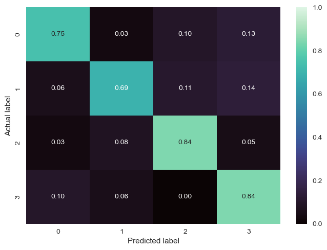

```python
ksvc_model_scaled = SVC(**params_ksvc_scaled)
res_ksvc_scaled = print_score(ksvc_model_scaled, data_tot_scaled)
print(classification_report(y_test_scaled, res_ksvc_scaled))
```

We can see that by allowing a SVM to have a kernel (gaussian in our case), the results of the confusion matrix increase a lot. This is due to the linear non-separability of the data in the space in which they lie. Instead, when we project those samples into a higher-dimensional space with a nonlinear (but accurate for our purpose) map, the data become "more separable" and the accuracy of the model benefits from that.

## Conclusions

```python
print(f'RAW DATASET: \n'
      f'\tParameters logistic: {params_logi} \n'
      f'\tParameters linearsvc: {params_svc} \n\n'
      f'\tAccuracy logistic on test: {round(accuracy_score(y_test, res_logi), 3)} \t Mean KFold CV logistic score: {round(kfold_score_logi, 3)}\n'
      f'\tAccuracy svc on test: {round(accuracy_score(y_test, res_svc), 3)} \t \t Mean KFold CV svc score: {round(kfold_score_svc, 3)}\n\n\n'
      'SCALED DATASET: \n'
      f'\tParameters logistic: {params_logi_scaled} \n'
      f'\tParameters linearsvc: {params_svc_scaled} \n\n'
      f'\tAccuracy logistic on test: {round(accuracy_score(y_test_scaled, res_logi_scaled), 3)} \t Mean KFold CV logistic score: {round(kfold_score_logi_scaled, 3)}\n'
      f'\tAccuracy svc on test: {round(accuracy_score(y_test_scaled, res_svc_scaled), 3)} \t \t Mean KFold CV svc score: {round(kfold_score_svc_scaled, 3)}')
```

```
RAW DATASET:
	Parameters logistic: {'C': 1.0, 'multi_class': 'ovr', 'n_jobs': 1, 'penalty': 'l1', 'solver': 'liblinear'}
	Parameters linearsvc: {'C': 10.0, 'loss': 'hinge', 'multi_class': 'crammer_singer', 'penalty': 'l2'}

	Accuracy logistic on test: 0.577 	 Mean KFold CV logistic score: 0.567
	Accuracy svc on test: 0.608 	 	 Mean KFold CV svc score: 0.562


SCALED DATASET:
	Parameters logistic: {'C': 1.0, 'l1_ratio': 0.5, 'multi_class': 'ovr', 'n_jobs': -1, 'penalty': 'elasticnet', 'solver': 'saga'}
	Parameters linearsvc: {'C': 1.0, 'loss': 'squared_hinge', 'multi_class': 'ovr', 'penalty': 'l1'}

	Accuracy logistic on test: 0.577 	 Mean KFold CV logistic score: 0.567
	Accuracy svc on test: 0.588 	 	 Mean KFold CV svc score: 0.56
```

For the above-mentioned reason, we decide to choose among the models that work on the raw dataset.

In conclusion, **we decide to use LinearSVC as our final model**: firstly, it has a higher overall accuracy (61% compared to 57% of LogisticRegression). Secondly, despite a ~3% decrease in accuracy for data with label 0, LinearSVC performs better on 2 and 3-labeled data by more than 7 and 8%, respectively. This makes us tend to prefer LinearSVC as our model of choice.

At the end, the overall accuracy is not really high, but this is due to the complex structure of the dataset, with low correlations among features and very weak single predictors of the label.

## Predictions

We now want to predict the sample provided.

```python
test = pd.read_csv('mldata_0003194123.TEST_FEATURES.csv', index_col='id')
test
```

| id | feature_1 | feature_2 | feature_3 | feature_4 | feature_5 | feature_6 | feature_7 | feature_8 | feature_9 | feature_10 | ... | feature_21 | feature_22 | feature_23 | feature_24 | feature_25 | feature_26 | feature_27 | feature_28 | feature_29 | feature_30 |
| --- | --- | --- | --- | --- | --- | --- | --- | --- | --- | --- | --- | --- | --- | --- | --- | --- | --- | --- | --- | --- | --- |
| 0 | 1.769616 | 3.052594 | 6.980585 | 6.438888 | 2.136025 | 2.617334 | -3.008321 | -3.321987 | -6.987982 | -0.318825 | ... | 1.636964 | 5.654286 | -1.546391 | 2.176126 | 4.717449 | 0.739977 | -4.805335 | 0.689606 | 0.182666 | -2.079089 |
| 1 | 1.735821 | 2.627245 | 0.153236 | 4.467896 | -0.343165 | -0.341733 | 3.060383 | -0.139706 | 1.561504 | 0.013081 | ... | 3.744956 | 0.881868 | 0.927650 | 3.438848 | 5.423029 | -1.715162 | -0.376928 | -3.314552 | -0.393005 | -1.325906 |
| 2 | -1.044644 | -4.512284 | 0.068175 | 1.609449 | -0.074739 | -0.298666 | -4.829141 | 0.185195 | -2.421023 | -1.201689 | ... | -0.474837 | 1.057899 | -0.596939 | -1.894807 | -8.537574 | -4.250275 | -4.608778 | 0.161415 | 1.640695 | 0.487163 |
| 3 | -0.268847 | -0.902760 | 1.185807 | -0.742148 | 5.316454 | -2.807416 | -2.201782 | -4.171063 | -2.797809 | -1.999702 | ... | 0.778357 | 5.684984 | 0.834202 | 2.222401 | 0.021671 | -2.706677 | -3.514754 | 1.056580 | 4.233931 | -1.632459 |
| 4 | -0.817995 | -0.237196 | -5.137207 | -3.217668 | -1.180586 | -0.751364 | -0.906787 | 1.348433 | 0.239462 | 0.546423 | ... | 3.296182 | 2.494865 | -2.757208 | -1.135564 | 3.577577 | 2.210097 | 3.444397 | 3.282480 | -0.995930 | 0.223214 |
| ... | ... | ... | ... | ... | ... | ... | ... | ... | ... | ... | ... | ... | ... | ... | ... | ... | ... | ... | ... | ... | ... |
| 1295 | 1.497135 | -3.317440 | -0.363473 | -1.567007 | 2.004570 | 2.238855 | -2.201309 | -0.222339 | 0.514084 | -1.897845 | ... | -1.477434 | 0.023790 | 1.123762 | -2.440807 | -4.663403 | -4.677472 | 1.211405 | -0.201721 | 0.683496 | -2.225260 |
| 1296 | -1.507250 | 1.158549 | -4.246182 | -2.267600 | 4.072917 | -0.362593 | 1.289554 | -1.907315 | 9.219071 | -0.670320 | ... | -4.954476 | -3.537849 | 2.449801 | 0.746340 | -3.893129 | -6.445453 | 3.235214 | 0.687497 | -0.869225 | -0.033149 |
| 1297 | 3.464990 | 7.033853 | 0.231720 | 4.035204 | 1.897736 | 2.478201 | -1.670055 | 0.645884 | 6.219050 | -3.929899 | ... | -2.687081 | -0.024692 | 3.436062 | 2.159725 | 9.360742 | 2.766805 | 2.787036 | -0.590809 | -0.541706 | -0.687629 |
| 1298 | -1.635168 | 2.574757 | 1.714622 | 2.162244 | -0.072002 | -0.189181 | 1.282689 | -0.001914 | 0.662624 | -1.640497 | ... | 2.472274 | 2.686034 | -1.210736 | -0.964075 | 2.611911 | -0.967108 | -1.574615 | -1.657991 | -0.391236 | -0.644969 |
| 1299 | -1.107076 | -3.270718 | -7.756660 | -10.235598 | -0.791800 | -0.402136 | 2.559805 | -0.378648 | -0.623918 | 2.236108 | ... | -0.531223 | 0.132898 | -1.088762 | 2.718372 | -1.522859 | 0.100035 | 3.435347 | -0.257212 | 0.041152 | 2.180142 |

1300 rows × 30 columns

```python
results = svc_model.predict(test)
results
```

```
array([1, 1, 2, ..., 1, 2, 3])
```

```python
np.savetxt('mldata_0003194123.TEST_LABELS_Mauloni.txt', results, fmt='%d', delimiter=',')
```